# Case Study 1

Austin Mangelson

2024-06-10

**Purpose:** The purpose of this documents is to:

1. Display my understanding of .Rmd files and syntax
2. Exercise my ability to understand and critique data driven visualization

# Critiquing Data Visualizations

## 1. The Least Affordable Cities in America

[figure not shown]

https://priceonomics.com/most-and-least-affordable-places-to-buy-a-home/

**What’s Good?**

- The visualization in a basic list format makes the data accessible and easy to understand.
- The organization from least to most is an easy way to quickly see the cities that are not affordable.

**What can be improved:**

- Of the top 50 least affordable cities, only 7 are not in California. To really drive this point home, I think a density map visualizing the most vs. least affordable areas would be more impactful.

## 2. Average Number of Marriages per Day

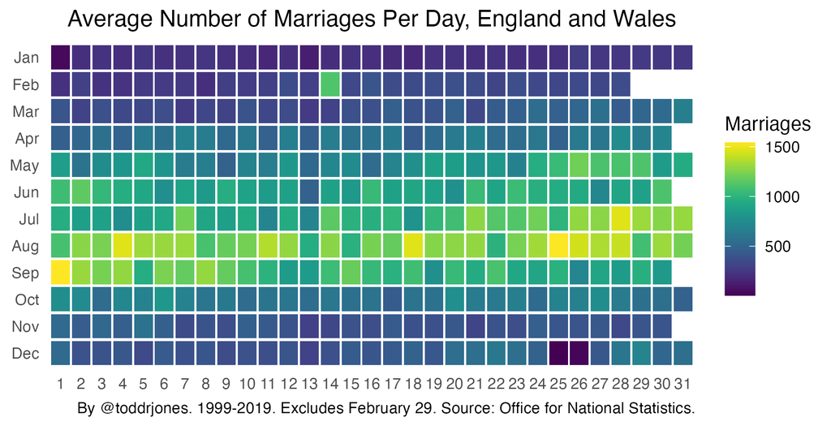

https://www.reddit.com/r/dataisbeautiful/comments/1dcpz5l/when_do_people_get_married_oc/

**What’s Good?**

- With this chart you can very quickly see that the summer months are by far the most popular times to get married.
- It’s an interesting way to visualize outlier trends (*for example, you can quickly gather that outside of the summer months, Valentines Day is a popular time to get married, while Christmas is avoided*)

**What can be improved:**

- The color hue choice is not intuitive. Instead, opting for a color saturation scale (*ex. light blue to dark blue*) might make a bit more sense.
- There is no way to quickly visualize weekend vs. weekday trends. Perhaps that needs to be a different graph entirely, but it would be interesting information.

[figure not shown]

https://priceonomics.com/survey-which-data-skills-do-you-need-to-get-ahead/

**What’s Good?**

**What can be improved:**

- It is unclear what each row’s skill is referring to (*skills vs success metrics?, etc.*)
- It is an extremely generalized visualization, and would be more valuable if it charted valuable data skills per industry.

## 4. Largest US Cities Ranked by 2022 Crime Rates

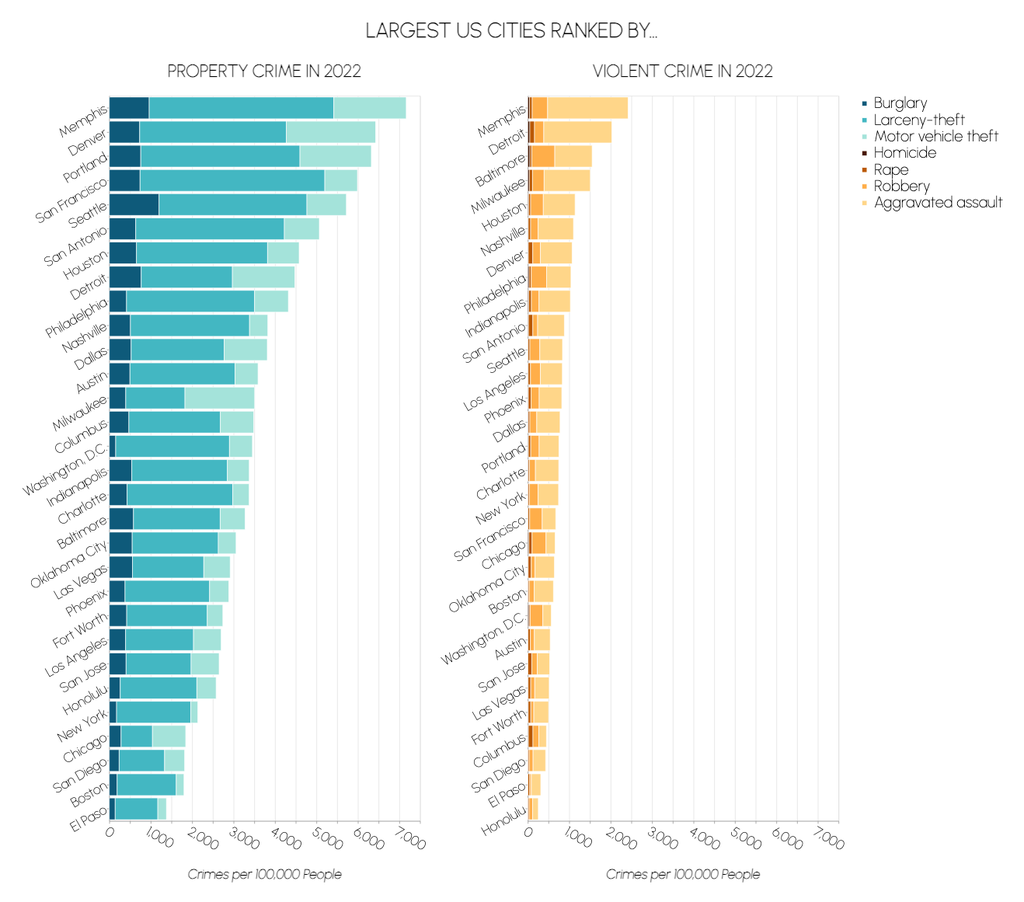

https://www.reddit.com/r/dataisbeautiful/comments/1dbzkgj/oc_largest_us_cities_ranked_by_2022_crime_rates/

**What’s Good?**

- The color hue differentiation between violent crime vs. property crime is useful in visualizing a difference in the amount of each type of crime.
- The stacked bar chart quickly displays differences in crimes within a given city.

**What can be improved:**

- The stacked bar chart makes it difficult to communicate crime rate trends between differing cities. A line chart would more easily communicate this information.
- I almost feel as if this is trying to contain/communicate too much information at once. Utilizing multiple charts to show differences in crime types, specific crimes, and between different cities would be useful.